# Cyclistic Google Capstone Project

Title - Google Data Analytics Capstone - Cyclistic / Author - Ryan Feryo / Date - 03/01/2025

Scenario You are a junior data analyst working on the marketing analyst team at Cyclistic, a bike-share company in Chicago. The director of marketing believes the company’s future success depends on maximizing the number of annual memberships. Therefore, your team wants to understand how casual riders and annual members use Cyclistic bikes differently. From these insights, your team will design a new marketing strategy to convert casual riders into annual members. But first, Cyclistic executives must approve your recommendations, so they must be backed up with compelling data insights and professional data visualizations.

Characters and teams ● Cyclistic: A bike-share program that features more than 5,800 bicycles and 600 docking stations. Cyclistic sets itself apart by also offering reclining bikes, hand tricycles, and cargo bikes, making bike-share more inclusive to people with disabilities and riders who can’t use a standard two-wheeled bike. The majority of riders opt for traditional bikes; about 8% of riders use the assistive options. Cyclistic users are more likely to ride for leisure, but about 30% use the bikes to commute to work each day.

● Lily Moreno: The director of marketing and your manager. Moreno is responsible for the development of campaigns and initiatives to promote the bike-share program. These may include email, social media, and other channels.

● Cyclistic marketing analytics team: A team of data analysts who are responsible for collecting, analyzing, and reporting data that helps guide Cyclistic marketing strategy. You joined this team six months ago and have been busy learning about Cyclistic’s mission and business goals—as well as how you, as a junior data analyst, can help Cyclistic achieve them.

● Cyclistic executive team: The notoriously detail-oriented executive team will decide whether to approve the recommended marketing program.

About the company In 2016, Cyclistic launched a successful bike-share offering. Since then, the program has grown to a fleet of 5,824 bicycles that are geotracked and locked into a network of 692 stations across Chicago. The bikes can be unlocked from one station and returned to any other station in the system anytime. Until now, Cyclistic’s marketing strategy relied on building general awareness and appealing to broad consumer segments. One approach that helped make these things possible was the exibility of its pricing plans: single-ride passes, full-day passes, and annual memberships. Customers who purchase single-ride or full-day passes are referred to as casual riders. Customers who purchase annual memberships are Cyclistic members. Cyclistic’s finance analysts have concluded that annual members are much more profitable than casual riders. Although the pricing exibility helps Cyclistic attract more customers, Moreno believes that maximizing the number of annual members will be key to future growth. Rather than creating a marketing campaign that targets all-new customers, Moreno believes there is a solid opportunity to convert casual riders into members. She notes that casual riders are already aware of the Cyclistic program and have chosen Cyclistic for their mobility needs. Moreno has set a clear goal: Design marketing strategies aimed at converting casual riders into annual members. In order to do that, however, the team needs to beer understand how annual members and casual riders differ, why casual riders would buy a membership, and how digital media could aect their marketing tactics. Moreno and her team are interested in analyzing the Cyclistic historical bike trip data to identify trends.

Moreno has assigned you the first question to answer: How do annual members and casual riders use Cyclistic bikes dierently?

Three questions will guide the future marketing program:

1. How do annual members and casual riders use Cyclistic bikes differently?
2. Why would casual riders buy Cyclistic annual memberships?
3. How can Cyclistic use digital media to infuence casual riders to become members?

Business Task:

Create ideas to convert casual riders to become annual members.

Description of all data sources used:

The data sources that were used were from the case study prompt. 12 months of rider data was used for the year 2024, compiled into a dataframe.

```python
import pandas as pd
import matplotlib.pyplot as plt
import seaborn as sns
import folium
```

```python
ride_files = [
    "202401-divvy-tripdata.csv",
    "202402-divvy-tripdata.csv",
    "202403-divvy-tripdata.csv",
    "202404-divvy-tripdata.csv",
    "202405-divvy-tripdata.csv",
    "202406-divvy-tripdata.csv",
    "202407-divvy-tripdata.csv",
    "202408-divvy-tripdata.csv",
    "202409-divvy-tripdata.csv",
    "202410-divvy-tripdata.csv",
    "202411-divvy-tripdata.csv",
    "202412-divvy-tripdata.csv"
]
dataframes = []

for ride_files in ride_files:
    df = pd.read_csv(ride_files)
    dataframes.append(df)

cyclistic_data = pd.concat(dataframes, ignore_index=True)

print(cyclistic_data.head())
```

```
            ride_id  rideable_type           started_at             ended_at  \
0  C1D650626C8C899A  electric_bike  2024-01-12 15:30:27  2024-01-12 15:37:59
1  EECD38BDB25BFCB0  electric_bike  2024-01-08 15:45:46  2024-01-08 15:52:59
2  F4A9CE78061F17F7  electric_bike  2024-01-27 12:27:19  2024-01-27 12:35:19
3  0A0D9E15EE50B171   classic_bike  2024-01-29 16:26:17  2024-01-29 16:56:06
4  33FFC9805E3EFF9A   classic_bike  2024-01-31 05:43:23  2024-01-31 06:09:35

           start_station_name start_station_id           end_station_name  \
0           Wells St & Elm St     KA1504000135   Kingsbury St & Kinzie St
1           Wells St & Elm St     KA1504000135   Kingsbury St & Kinzie St
2           Wells St & Elm St     KA1504000135   Kingsbury St & Kinzie St
3      Wells St & Randolph St     TA1305000030  Larrabee St & Webster Ave
4  Lincoln Ave & Waveland Ave            13253   Kingsbury St & Kinzie St

  end_station_id  start_lat  start_lng    end_lat    end_lng member_casual
0   KA1503000043  41.903267 -87.634737  41.889177 -87.638506        member
1   KA1503000043  41.902937 -87.634440  41.889177 -87.638506        member
2   KA1503000043  41.902951 -87.634470  41.889177 -87.638506        member
3          13193  41.884295 -87.633963  41.921822 -87.644140        member
4   KA1503000043  41.948797 -87.675278  41.889177 -87.638506        member
```

```python
cyclistic_data['started_at'] = cyclistic_data['started_at'].astype(str).str.replace(r'\.\d+', '', regex=True)
cyclistic_data['started_at'] = pd.to_datetime(cyclistic_data['started_at'], errors='coerce')
cyclistic_data['started_at'] = cyclistic_data['started_at'].dt.strftime('%Y-%m-%d %H:%M:%S')
print(cyclistic_data[['started_at']].tail())
```

```
                  started_at
5860563  2024-12-11 08:23:46
5860564  2024-12-09 12:26:15
5860565  2024-12-31 17:10:03
5860566  2024-12-01 14:39:47
5860567  2024-12-17 06:38:32
```

```python
cyclistic_data['ended_at'] = cyclistic_data['ended_at'].astype(str).str.replace(r'\.\d+', '', regex=True)
cyclistic_data['ended_at'] = pd.to_datetime(cyclistic_data['ended_at'], errors='coerce')
cyclistic_data['ended_at'] = cyclistic_data['ended_at'].dt.strftime('%Y-%m-%d %H:%M:%S')
print(cyclistic_data[['ended_at']].tail())
```

```
                    ended_at
5860563  2024-12-11 08:37:34
5860564  2024-12-09 12:37:32
5860565  2024-12-31 17:17:21
5860566  2024-12-01 14:45:21
5860567  2024-12-17 06:46:27
```

```python
duplicates = cyclistic_data[cyclistic_data.duplicated(keep=False)]
duplicates = duplicates.drop_duplicates().reset_index(drop=True)
duplicates
```

|  | ride_id | rideable_type | started_at | ended_at | start_station_name | start_station_id | end_station_name | end_station_id | start_lat | start_lng | end_lat | end_lng | member_casual |
| --- | --- | --- | --- | --- | --- | --- | --- | --- | --- | --- | --- | --- | --- |
| 0 | 2C772EDDDBDEFDA3 | electric_bike | 2024-05-31 23:42:42 | 2024-06-01 00:25:08 | Dearborn St & Van Buren St | 624 | DuSable Lake Shore Dr & Monroe St | 13300 | 41.876054 | -87.629921 | 41.880958 | -87.616743 | casual |
| 1 | 0D8EF5177D598456 | classic_bike | 2024-05-31 20:59:29 | 2024-06-01 21:59:22 | Wentworth Ave & Cermak Rd* | chargingstx07 | NaN | NaN | 41.853214 | -87.631872 | NaN | NaN | casual |
| 2 | 7BC67FD33887B3CB | classic_bike | 2024-05-31 22:54:20 | 2024-06-01 00:42:41 | Burnham Harbor | 15545 | St. Louis Ave & Fullerton Ave | KA1504000090 | 41.857412 | -87.613792 | 41.924816 | -87.714495 | casual |
| 3 | 43CD52984AD22D99 | electric_bike | 2024-05-31 23:45:51 | 2024-06-01 00:11:46 | Wentworth Ave & Cermak Rd* | chargingstx07 | Loomis St & Lexington St | 13332 | 41.853098 | -87.631871 | 41.872229 | -87.661364 | member |
| 4 | ABBD88BEBC1431FF | electric_bike | 2024-05-31 23:20:35 | 2024-06-01 00:33:41 | McClurg Ct & Erie St | KA1503000041 | McClurg Ct & Erie St | KA1503000041 | 41.894351 | -87.617765 | 41.894503 | -87.617854 | casual |
| ... | ... | ... | ... | ... | ... | ... | ... | ... | ... | ... | ... | ... | ... |
| 206 | 99AC3F84299D51E2 | electric_bike | 2024-05-31 23:40:50 | 2024-06-01 00:06:38 | Public Rack - Clyde Ave & 87th St | 986 | NaN | NaN | 41.737184 | -87.573007 | 41.730000 | -87.580000 | casual |
| 207 | D55108DEEE45D0E6 | classic_bike | 2024-05-31 18:21:43 | 2024-06-01 19:21:21 | Wells St & Elm St | KA1504000135 | NaN | NaN | 41.903222 | -87.634324 | 41.910000 | -87.680000 | casual |
| 208 | 6457A0484EBEEB09 | classic_bike | 2024-05-31 11:06:59 | 2024-06-01 12:06:55 | Dauphin Ave & 87th St | 20116 | NaN | NaN | 41.736480 | -87.601252 | NaN | NaN | casual |
| 209 | 532780A49B9089CD | electric_bike | 2024-05-31 23:57:45 | 2024-06-01 00:13:39 | Public Rack - Garfield Park Conservatory | 1059 | NaN | NaN | 41.886529 | -87.716723 | 41.890000 | -87.770000 | casual |
| 210 | AF64DCDB78A7E980 | electric_bike | 2024-05-31 23:38:44 | 2024-06-01 00:33:46 | Lincoln Ave & Sunnyside Ave | TA1307000156 | NaN | NaN | 41.963081 | -87.684857 | 41.960000 | -87.660000 | member |

211 rows × 13 columns

```python
missing_values = cyclistic_data.isnull().sum()
missing_values
```

```
ride_id                     0
rideable_type               0
started_at                  0
ended_at                    0
start_station_name    1073951
start_station_id      1073951
end_station_name      1104653
end_station_id        1104653
start_lat                   0
start_lng                   0
end_lat                  7232
end_lng                  7232
member_casual               0
dtype: int64
```

```python
cyclistic_data['start_station_name'] = cyclistic_data['start_station_name'].fillna('Not Listed')
cyclistic_data['start_station_id'] = cyclistic_data['start_station_id'].fillna('Not Listed')
```

```python
cyclistic_data['end_station_name'] = cyclistic_data['end_station_name'].fillna('Not Listed')
cyclistic_data['end_station_id'] = cyclistic_data['end_station_id'].fillna('Not Listed')
```

```python
cyclistic_data = cyclistic_data.dropna(subset=['end_lat', 'end_lng'])
```

```python
missing_values = cyclistic_data.isnull().sum()
missing_values
```

```
ride_id               0
rideable_type         0
started_at            0
ended_at              0
start_station_name    0
start_station_id      0
end_station_name      0
end_station_id        0
start_lat             0
start_lng             0
end_lat               0
end_lng               0
member_casual         0
dtype: int64
```

```python
cyclistic_data.dtypes
```

```
ride_id                object
rideable_type          object
started_at             object
ended_at               object
start_station_name     object
start_station_id       object
end_station_name       object
end_station_id         object
start_lat             float64
start_lng             float64
end_lat               float64
end_lng               float64
member_casual          object
dtype: object
```

```python
cyclistic_data['started_at'] = pd.to_datetime(cyclistic_data['started_at'], errors='coerce')
cyclistic_data['ended_at'] = pd.to_datetime(cyclistic_data['ended_at'], errors='coerce')
cyclistic_data['ride_duration'] = cyclistic_data['ended_at'] - cyclistic_data['started_at']
print(cyclistic_data[['started_at', 'ended_at', 'ride_duration']].head())
```

```
           started_at            ended_at   ride_duration
0 2024-01-12 15:30:27 2024-01-12 15:37:59 0 days 00:07:32
1 2024-01-08 15:45:46 2024-01-08 15:52:59 0 days 00:07:13
2 2024-01-27 12:27:19 2024-01-27 12:35:19 0 days 00:08:00
3 2024-01-29 16:26:17 2024-01-29 16:56:06 0 days 00:29:49
4 2024-01-31 05:43:23 2024-01-31 06:09:35 0 days 00:26:12
```

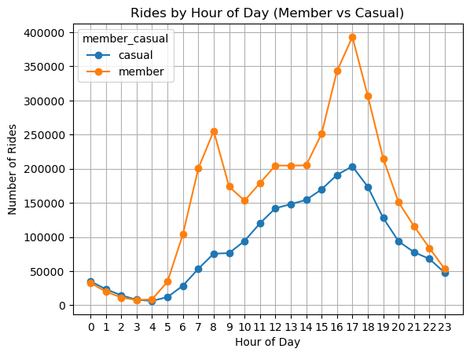

```python
# Creating graph to show number of rides each hour of the day between members and casual riders
cyclistic_data['hour_of_day'] = cyclistic_data['started_at'].dt.hour

hourly_counts = cyclistic_data.groupby(['hour_of_day', 'member_casual']).size().reset_index(name='ride_count')
plot_hour_data = hourly_counts.pivot(index='hour_of_day', columns='member_casual', values='ride_count')

plt.figure(figsize=(10, 6))
plot_hour_data.plot(kind='line', marker='o', title='Rides by Hour of Day (Member vs Casual)', xlabel='Hour of Day', ylabel='Number of Rides')
plt.xticks(range(24))
plt.grid(True)
plt.show()
```

The difference between casual riders and annual members is that members use the bikes more to commute to and from work as we can see peaks during 8-9am and 5-6pm. Bike usage for casual riders is spread out more evenly throughout the day.

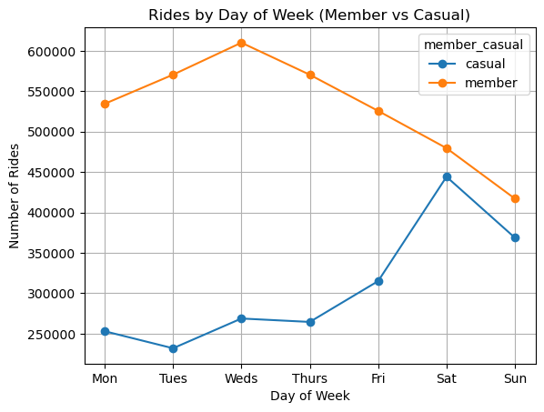

```python
# Creating graph to show number of rides per day of week between members and casual riders
cyclistic_data['day_of_week'] = cyclistic_data['started_at'].dt.dayofweek
daily_counts = cyclistic_data.groupby(['day_of_week', 'member_casual']).size().reset_index(name='ride_count')
plot_day_data = daily_counts.pivot(index='day_of_week', columns='member_casual', values='ride_count')

plt.figure(figsize=(10, 6))
plot_day_data.plot(kind='line', marker='o', title='Rides by Day of Week (Member vs Casual)', xlabel='Day of Week', ylabel='Number of Rides')
plt.xticks(ticks=range(7), labels=['Mon', 'Tues', 'Weds', 'Thurs', 'Fri', 'Sat', 'Sun'])
plt.grid(True)
plt.show()
```

To no surprise, annual members use the bikes more during the week as we saw higher number of rides while members commute to work. Whereas casual riders who the bikes more during the weekend. This shows that casual riders are not deriving value during the week which causes them to not see the value in subscribing to an annual membership.

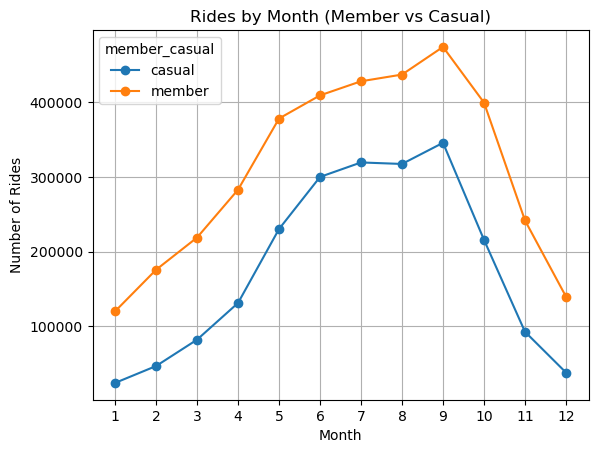

```python
# Creating graph to show number of rides per month between members and casual riders.
cyclistic_data['month'] = cyclistic_data['started_at'].dt.month
monthly_counts = cyclistic_data.groupby(['month', 'member_casual']).size().reset_index(name='ride_count')
plot_month_data = monthly_counts.pivot(index='month', columns='member_casual', values='ride_count')

plt.figure(figsize=(10, 6))
plot_month_data.plot(kind='line', marker = 'o', title='Rides by Month (Member vs Casual)', xlabel='Month', ylabel='Number of Rides')
plt.xticks(range(1, 13))
plt.grid(True)
plt.show()
```

There is not a noticable difference in trend between casual riders and annual members in terms of using bikes at different months of the year. Most of the bikes are being used during months in the middle of the year when the weather is warmer. A reason the casual riders feel the annual membership is not worth the money is because they do not use the bikes during the colder months of the year, so it is more woth it for casual riders to use the bikes as needed and pay for single rides or day passes.

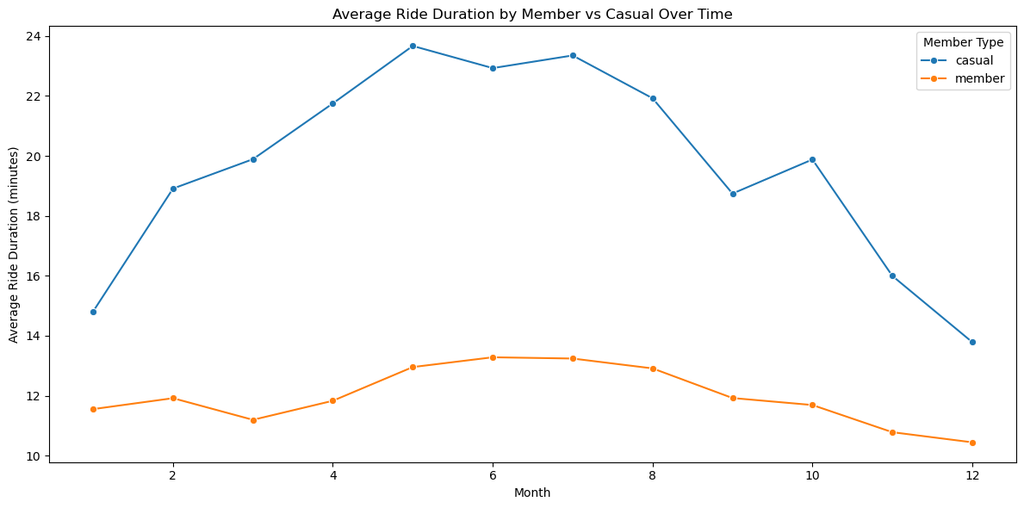

```python
# Creating graph that shows average ride duration each month between members and casual riders
cyclistic_data['ride_duration'] = cyclistic_data['ended_at'] - cyclistic_data['started_at']
cyclistic_data['ride_duration_minutes'] = cyclistic_data['ride_duration'].dt.total_seconds() / 60
cyclistic_data['month'] = cyclistic_data['started_at'].dt.month

avg_ride_duration = cyclistic_data.groupby(['month', 'member_casual'])['ride_duration_minutes'].mean().reset_index()

plt.figure(figsize=(12, 6))
sns.lineplot(data=avg_ride_duration, x='month', y='ride_duration_minutes', hue='member_casual', marker='o')
plt.title('Average Ride Duration by Member vs Casual Over Time')
plt.xlabel('Month')
plt.ylabel('Average Ride Duration (minutes)')
plt.legend(title='Member Type')
plt.tight_layout()
plt.show()
```

There is a huge gap between average ride duration between casual riders and annual members. One reason for this might be that annual riders mainly use the bikes to commute to and from work, their commutes are perfectly suitable for using bikes as their commutes are too far to walk but not nearly as far for the need to take public transport. With casual riders, the bikes are mainly used by weekend users and tourists, where the bikes are used to explore the city are are not primarily used to strictly get from one destination to another efficiently.

```python
# Total counts for each 'rideable_type'
rideable_type_counts = cyclistic_data['rideable_type'].value_counts()
print(rideable_type_counts)
```

```
rideable_type
electric_bike       2980595
classic_bike        2728404
electric_scooter     144337
Name: count, dtype: int64
```

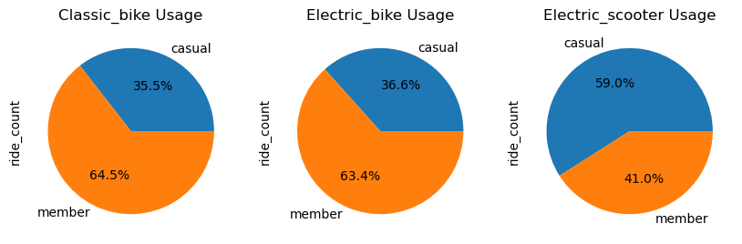

```python
# Creating pie charts to show distribution of usage of each rideable type between members and casual riders
rideable_counts = cyclistic_data.groupby(['rideable_type', 'member_casual']).size().reset_index(name='ride_count')
rideable_types = ['classic_bike', 'electric_bike', 'electric_scooter']

plt.figure(figsize=(24, 20))
for i, rideable_type in enumerate(rideable_types, 1):
    rideable_data = rideable_counts[rideable_counts['rideable_type'] == rideable_type]
    plt.subplot(1, 3, i)
    rideable_data.set_index('member_casual')['ride_count'].plot(kind='pie', autopct='%1.1f%%', title=f'{rideable_type.capitalize()} Usage', legend=False, figsize=(10, 10))

plt.show()
```

The proportion of classic bikes and electric bikes between casual riders and annual members are similiar and do not show major significance. However, even though the electric scooter rides only account for about 2% of the total rides, a lot more casual riders tend to ride them over members.

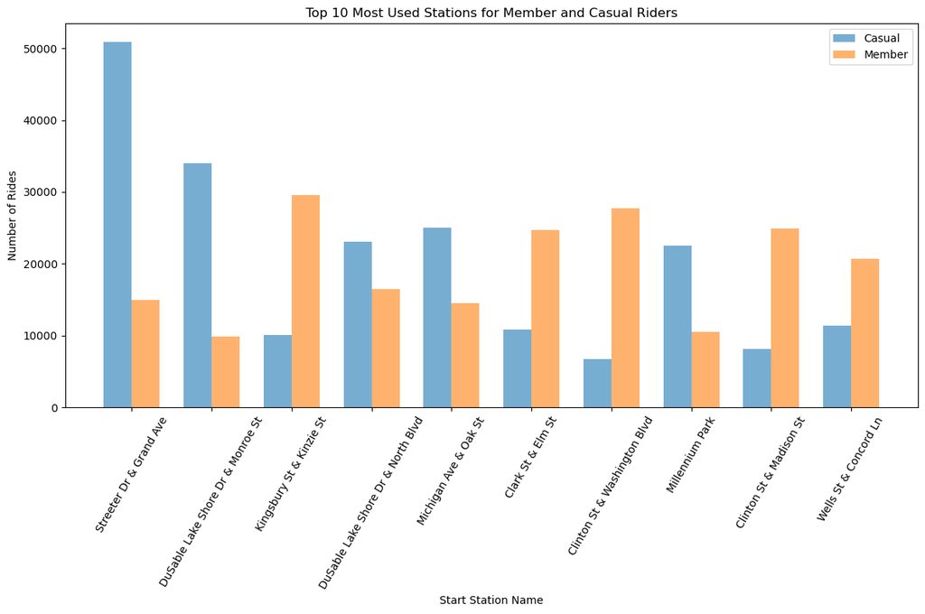

```python
# Creating graph for the top 10 most used stations for members and casual riders separately
cyclistic_data = cyclistic_data[cyclistic_data['start_station_name'] != 'Not Listed']
station_counts = cyclistic_data.groupby(['start_station_name', 'member_casual']).size().reset_index(name='count')

pivot_station_counts = station_counts.pivot(index='start_station_name', columns='member_casual', values='count').fillna(0)
pivot_station_counts['total'] = pivot_station_counts['member'] + pivot_station_counts['casual']
top_10_stations = pivot_station_counts.sort_values(by='total', ascending=False).head(10)

bar_width = 0.35
index = range(len(top_10_stations))
fig, ax = plt.subplots(figsize=(12, 8))

ax.bar([i - bar_width / 2 for i in index], top_10_stations['casual'], label='Casual', alpha=0.6, width=bar_width)
ax.bar([i + bar_width / 2 for i in index], top_10_stations['member'], label='Member', alpha=0.6, width=bar_width)

plt.xticks(index, top_10_stations.index, rotation=60)

plt.xlabel('Start Station Name')
plt.ylabel('Number of Rides')
plt.title('Top 10 Most Used Stations for Member and Casual Riders')
plt.legend()
plt.tight_layout()
plt.show()
```

The stations that are more frequently used by casual riders are in places near parks and more tourist attractions, where people visiting Chicago or people on the weekends tend to be. Whereas the stations that annual members use more frequently are in areas that are densly populated. All of these stations where annual members use the stations more are located outside The Loop in Chicago, which is where most of the business buildings in Chicago are located. These stations are mostly for commuters to commute into The Loop for work using the bikes having to cross over the Chicago River.

```python
# Creating map to show top 10 locations for casual riders picking up bikes
casual_data = cyclistic_data[cyclistic_data['member_casual'] == 'casual']
location_counts = casual_data.groupby(['start_lat', 'start_lng']).size().reset_index(name='count')
top_10_locations = location_counts.sort_values(by='count', ascending=False).head(10)

map = folium.Map(location=[top_10_locations['start_lat'].mean(), top_10_locations['start_lng'].mean()], zoom_start=12)

for index, row in top_10_locations.iterrows():
    folium.Marker(
        location=[row['start_lat'], row['start_lng']],
        popup=f"Lat: {row['start_lat']}, Lng: {row['start_lng']}, Rides: {row['count']}",
        icon=folium.Icon(color='blue', icon='info-sign')
    ).add_to(map)

map
```

Make this Notebook Trusted to load map: File -> Trust Notebook

[interactive chart not shown]

Based on the map shown, the top 10 stations for casual riders are in areas near parks and other popular tourist attractions. They are popular places on the weekends and during the summer months. These places are a lot more rider friendly, with these locations being more scenic and with riders having to worry less about trafficy areas. It also makes sense as to why more casual riders use these locations because they are not commuting to and from work.

Top 3 Recommendations

- Create an annual weekend membership plan for casual riders. A less expensive plan as an option for people who dont use the bikes during the week and only allow those members to use the bikes during the weekend. Similarly, create a semi-annual or quarterly membership to cater to the casual members as the data shows most casual members use the bikes during the months between May and October.
- Create annual park passes for members to only be allowed to use bikes in the top 10 stations for casual members at a discounted price.
- Implement a 2 week free trial of the membership for casual riders to see if an annual membership would be worth subscribing for. With the other recommendations implemented. It gives the rider more options to choose from to best suit their needs if they decide to decide to become a member
- BONUS: Even though the electric scooters only account for just over 2% of the toal riders, becuse there is a huge difference in usage between annual members and casual riders. Create an electric scooter only membership. If a scooter only membership can convert casual riders to where the ratio between members and riders is a similiar level to that of the bikes, thats over 30,000 people converted to an annual membership.